# Week 1-1. Numeric and graphic summary

< Back to Syllabus

## Week 1-1. Numeric and graphic summary

Before we start … let’s install R packages first!

```r
install.packages(c("tidyverse", "gapminder"))
```

```r
library(tidyverse)
library(gapminder)
```

### 1. Data types

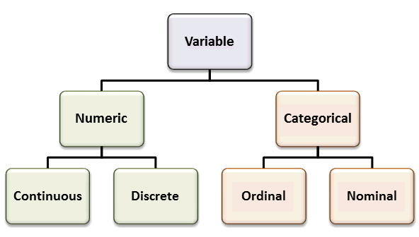

e.g.

- Numeric-Continuous: height, weight, age, etc.
- Numeric-Discrete: number of hospitalization to hospital A
- Categorical-Ordinal: satisfaction score on a scale of 1-not at all happy to 5-very happy
- Categorical-Nominal: 1-male/0-female, 1-smoker/0-non-smoker

### 2. Histogram

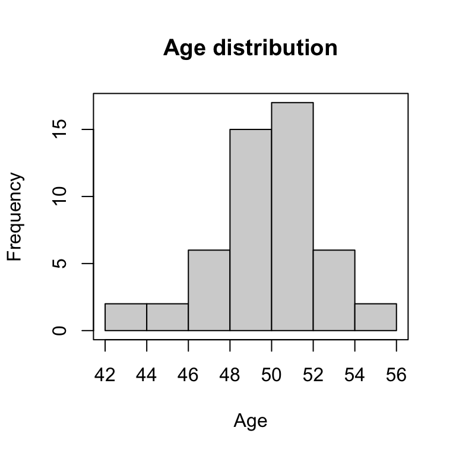

- A `histogram` plots the distribution of a numeric variable’s values using bars
- Cannot plot a histogram with a categorical variable!
- Histogram is about only one single variable. Histogram does not show the relationship of two variables.
- Each bar represents a range of numeric values called “bin” or “class”
- A bar’s height = frequency of data points with a value within the corresponding bin.

[R code]

```r
# Load the 'gapminder' dataset
df <- gapminder

# Print first 6 rows
head(df)
```

```
## # A tibble: 6 x 6
##   country     continent  year lifeExp      pop gdpPercap
##   <fct>       <fct>     <int>   <dbl>    <int>     <dbl>
## 1 Afghanistan Asia       1952    28.8  8425333      779.
## 2 Afghanistan Asia       1957    30.3  9240934      821.
## 3 Afghanistan Asia       1962    32.0 10267083      853.
## 4 Afghanistan Asia       1967    34.0 11537966      836.
## 5 Afghanistan Asia       1972    36.1 13079460      740.
## 6 Afghanistan Asia       1977    38.4 14880372      786.
```

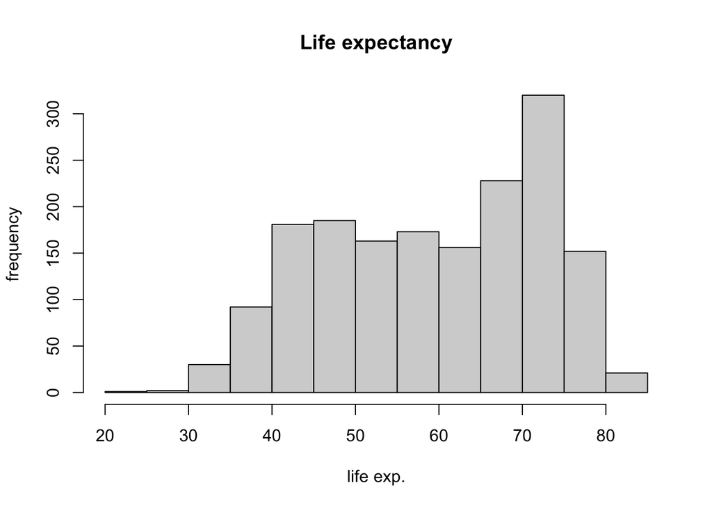

```r
# Plot a histogram of life expectancy
hist(df$lifeExp,
     main = "Life expectancy", # plot title,
     xlab = "life exp.", # x-axis label
     ylab = "frequency", # y-axis label
     breaks = "FD" # number of bins
     )
```

- For more methods on how to determine the number of bins, please click [HERE](https://r-charts.com/distribution/histogram-breaks/).

### 3. Multiple histograms in one screen

- `par(mfrow = c(1, 2))`: makes side-by-side plots
- Here, `c(1, 2)` indicates the number of rows and columns.

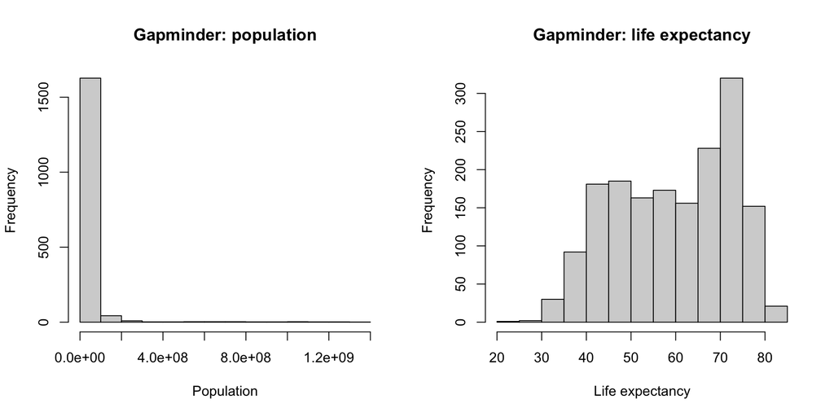

```r
par(mfrow = c(1, 2))
hist(df$pop, main = "Gapminder: population", xlab = "Population")
hist(df$lifeExp, main = "Gapminder: life expectancy", xlab = "Life expectancy")
```

### 4. Summary statistics

- mean: `mean()`
- median: `median()`
- standard deviation: `sd()`
- variance: `var()`
- quantile: `quantile()`
- minimum: `min()`
- maximum: `max()`
- `summary()` can show these numeric summaries at once

```r
mean(df$lifeExp)
```

```
## [1] 59.47444
```

```r
median(df$lifeExp)
```

```
## [1] 60.7125
```

```r
sd(df$lifeExp)
```

```
## [1] 12.91711
```

```r
var(df$lifeExp)
```

```
## [1] 166.8517
```

```r
quantile(df$lifeExp)
```

```
##      0%     25%     50%     75%    100%
## 23.5990 48.1980 60.7125 70.8455 82.6030
```

```r
min(df$lifeExp)
```

```
## [1] 23.599
```

```r
max(df$lifeExp)
```

```
## [1] 82.603
```

```r
summary(df$lifeExp)
```

```
##    Min. 1st Qu.  Median    Mean 3rd Qu.    Max.
##   23.60   48.20   60.71   59.47   70.85   82.60
```

< Back to Syllabus